# Machine Learning Using Titanic Dataset (Exploratory Analysis)

Himansu Sahoo

October 15, 2015

### Read the dataset

```r
#train_raw <- read.csv(file="../titanic-train.csv")
#test_raw <- read.csv(file="../titanic-test.csv")
train_raw <- read.csv(file="../titanic-train.csv", na.strings=c("", " ", "NA", "NAN"))
test_raw <- read.csv(file="../titanic-test.csv", na.strings=c("", " ", "NA", "NAN"))
# treat all empty values, NAN as NA's
```

#### Step 1 : check the dimensions, length, class of variables

```r
dim(train_raw)
```

```
## [1] 891  12
```

```r
# train_raw has 891 rows/observations and 12 variables.
#names(train_raw)
#sapply(train_raw, length) # all variables have same length
sapply(train_raw, class)
```

```
## PassengerId    Survived      Pclass        Name         Sex         Age
##   "integer"   "integer"   "integer"    "factor"    "factor"   "numeric"
##       SibSp       Parch      Ticket        Fare       Cabin    Embarked
##   "integer"   "integer"    "factor"   "numeric"    "factor"    "factor"
```

```r
dim(test_raw)
```

```
## [1] 418  11
```

```r
# test_raw has 418 rows/observations and 11 variables.
#names(test_raw)
#sapply(test_raw, length) # all variables have same length
#sapply(test_raw, class)
#head(train_raw)
#head(test_raw)
```

Just looking at these, test_raw has one variable less, Survived, which is the response/target variable. All variables have same length. test_raw variables have same class as train_raw.

#### Step 2 : `str()`, `summary()`, `head()`, `tail()` of the dataset

```r
#str(train_raw)
#str(test_raw)
#head(train_raw, n=100) # print first 100 rows
#summary(train_raw)
#summary(test_raw)
```

Looking at `str()` for the dataset four variables; PassengerId, Name, Ticket, Cabin are just unique identifiers for each person. They are not helpful for the model. remove the variables. looking at `head(dataset, n=100)`, there are lots of data are missing in Cabin variable. It will be helpful to read them as NA’s by modifing the `read.csv()` command.

Looking at `summary(train_raw)`, we see Age has 177 NA’s, Cabin has 687 NA’s, Embarked has 2 NA’s.

similarly in `summary(test_raw)`, we see Age has 86 NA’s, Fare has 1 NA, Cabin has 327 NA’s.

#### Step 3 : Data cleaning : Missing value treatment

```r
#colSums(is.na(train_raw)) # will shows NA's for each variable
#colSums(is.na(test_raw))
func_ratioNA <- function(x) length(x[x==""])/length(x)
perc_NA <- apply(train_raw, 2, FUN = func_ratioNA)
print(perc_NA) # percentage of NA's in the dataset
```

```
## PassengerId    Survived      Pclass        Name         Sex         Age
## 0.000000000 0.000000000 0.000000000 0.000000000 0.000000000 0.198653199
##       SibSp       Parch      Ticket        Fare       Cabin    Embarked
## 0.000000000 0.000000000 0.000000000 0.000000000 0.771043771 0.002244669
```

Age has 20%, Cabin has 77%, Embarked has 0.2% missing values. Rules of thumb is to discard the variable having more than 30% missing values.

```r
#names(train_raw)
train_cleaned <- train_raw[, -which(perc_NA>0.30)]
#names(train_cleaned) # Cabin is removed
cat("train_cleaned : dimension :  ", dim(train_cleaned) , "\n")
```

```
## train_cleaned : dimension :   891 11
```

```r
remove_trainvar <- names(train_cleaned) %in% c("PassengerId", "Name", "Ticket", "Cabin")
train_final <- train_cleaned[, !remove_trainvar]
#names(train_final) # "PassengerId", "Name", "Ticket", "Cabin" are removed
cat("train_final : dimension :  ", dim(train_final) , "\n")
```

```
## train_final : dimension :   891 8
```

```r
apply(train_final, 2, FUN = func_ratioNA)
```

```
##    Survived      Pclass         Sex         Age       SibSp       Parch
## 0.000000000 0.000000000 0.000000000 0.198653199 0.000000000 0.000000000
##        Fare    Embarked
## 0.000000000 0.002244669
```

#### Step 4 : Data cleaning for test_data

```r
remove_testvar <- names(test_raw) %in% c("PassengerId", "Name", "Ticket", "Cabin")
test_final <- test_raw[, !remove_testvar]
cat("test_final : dimension :  ", dim(test_final) , "\n")
```

```
## test_final : dimension :   418 7
```

```r
apply(test_final, 2, FUN = func_ratioNA)
```

```
##      Pclass         Sex         Age       SibSp       Parch        Fare
## 0.000000000 0.000000000 0.205741627 0.000000000 0.000000000 0.002392344
##    Embarked
## 0.000000000
```

#### Step 5 : Data visualization

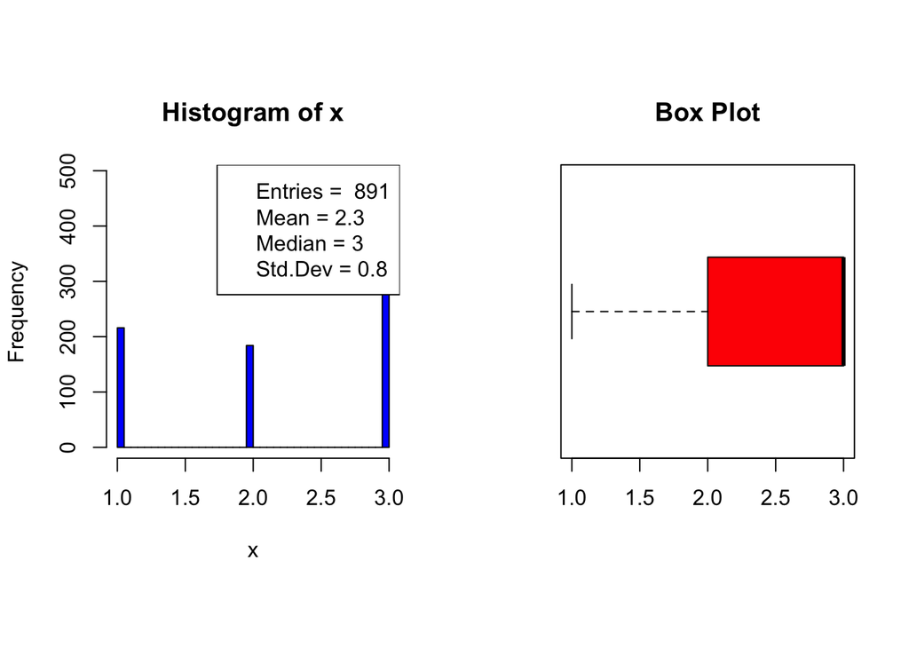

```r
plotvar(train_final$Pclass)
```

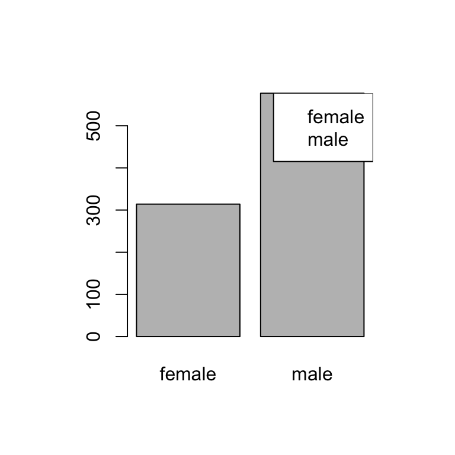

```r
plotvar(train_final$Sex)
```

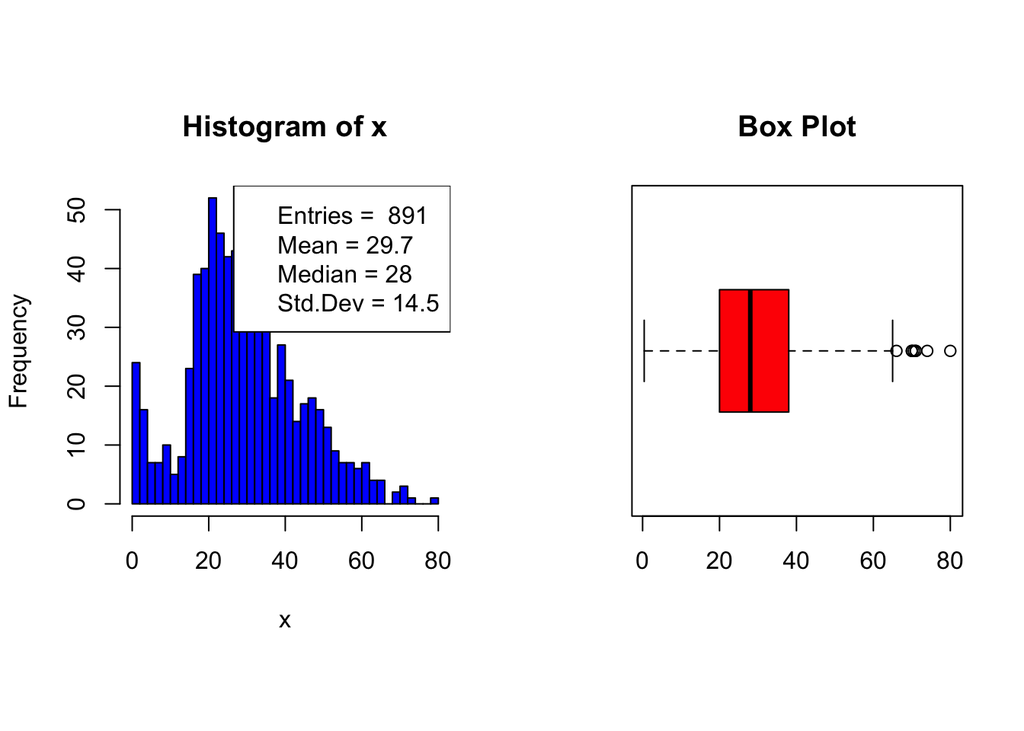

```r
plotvar(train_final$Age)
```

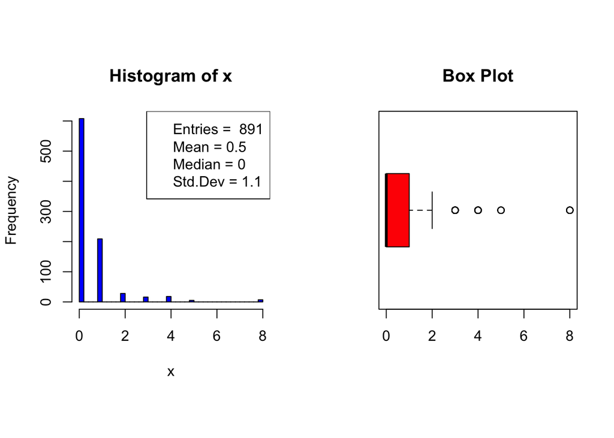

```r
plotvar(train_final$SibSp)
```

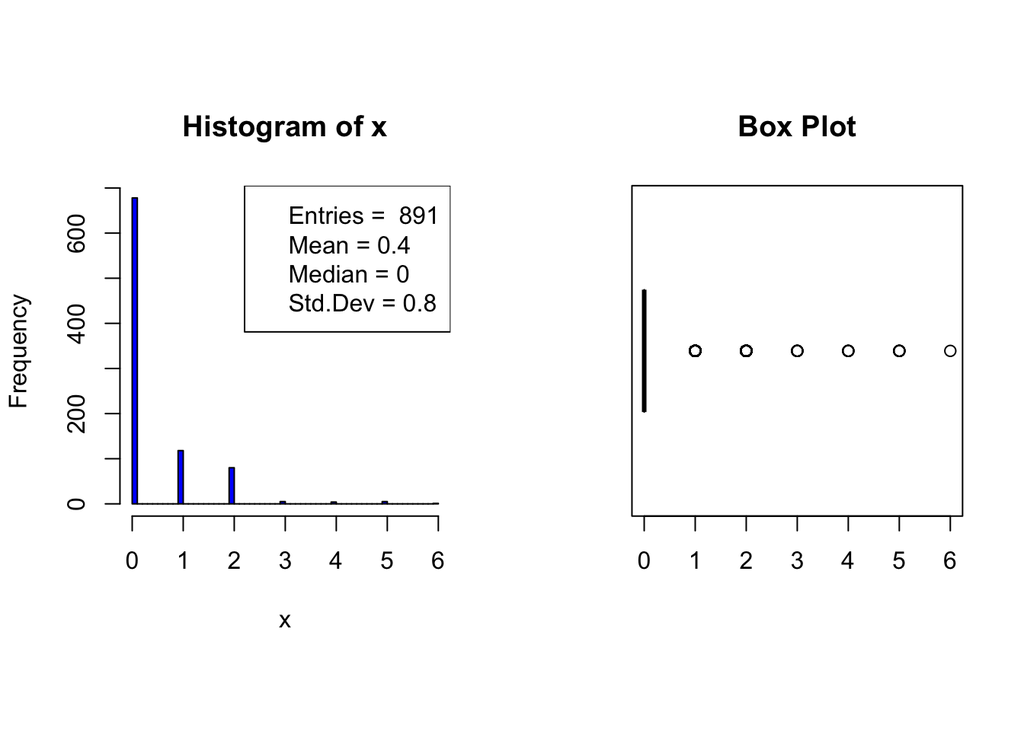

```r
plotvar(train_final$Parch)
```

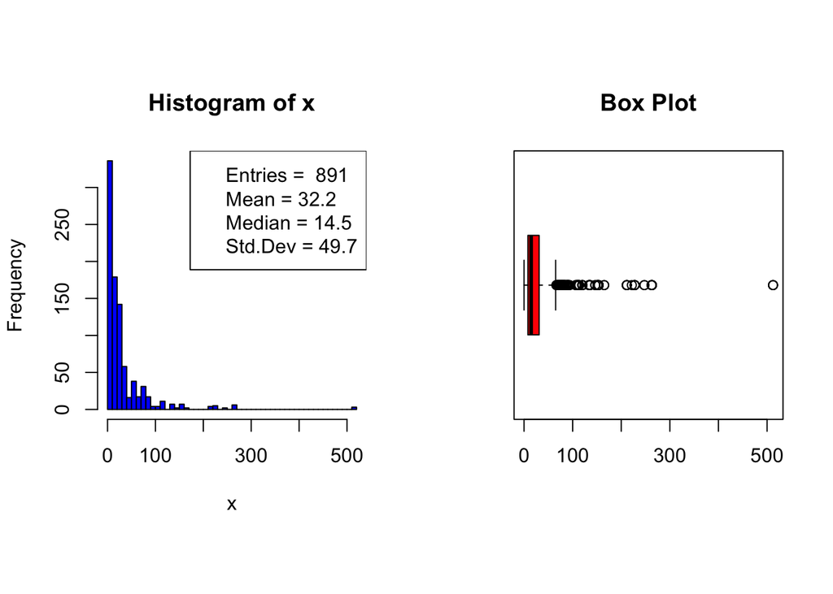

```r
plotvar(train_final$Fare)
```

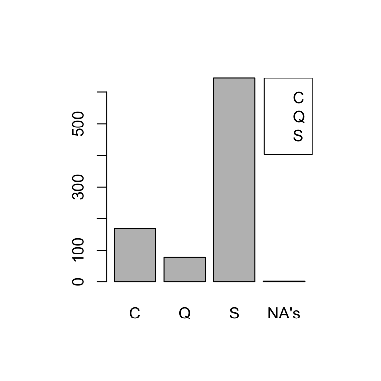

```r
plotvar(train_final$Embarked)
```

#### Step 6 : Data cleaning : Checking Outliers

Looking at the box plot for Fare variable, there is lots of data outside the IQR.

```r
perc_outlier(train_final$Fare) # to check percentage of outlier
```

```
## [1] 0.1301908
```

```r
# 13\% of Fare data are outlier. Lets keep it now. we will study later.
```